# Activities

# Lectures

## Lecture Times

Lectures will be delivered live, in dual mode (both on Zoom and in person) in the following venue:

- [PG] PAR-FBE-211 (Theatre 2), Mondays, from 11:05am to 1:00pm
- [UG] PAR-The Spot-4007, Mondays, from 2.15pm to 4.15pm

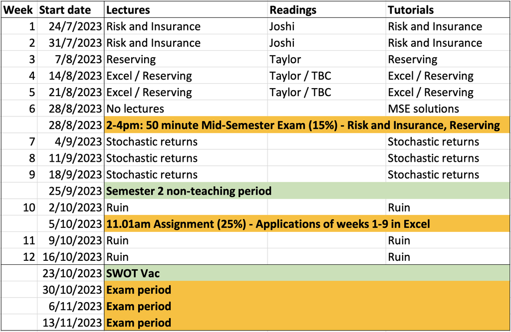

Notes:

Note this subject is one-quarter of a standard load. That means, including attendance at classes, you should be putting the equivalent of one quarter of a week’s work into this subject, i.e. 9 to 10 hours.

## Lecture Slides and Materials

All materials are available on this website.

The most salient exception are lecture recordings, with annotated slides, which are cohort specific, and which will be available with the associated recording on Echo360.

## Recorded Lectures

Audio and video recordings of lectures delivered in this subject will be made available for review. These recordings allow you to revise lectures during the semester, or to review them in preparation for the end of semester exam.

You can access recorded lectures by clicking on the “Lecture Capture” menu item on the LMS page for this subject.

**Recordings are not a substitute for attendance**; rather they are designed for revision. On rare occasions the recordings can fail to take place due to technical reasons. In such cases, a substitute recording will **not** be made available.

# Tutorials

## Tutorial Times

Tutorials start in week 1. Please check your timetable and the University timetable https://sws.unimelb.edu.au/2023/ for details. You must attend the tutorials you are enrolled in.

Tutorials will not be recorded.

## Tutorial Details and Materials

The tutorial schedule is provided in the plan above.

Please attempt tutorial exercises before your tutorial, and come prepared with questions.

## Private Tutoring Services

The Faculty has become increasingly concerned about the existence of a number of private tutoring services operating in Melbourne that heavily target University of Melbourne students enrolled in FBE subjects.

Students are urged to show caution and exercise their judgement if they are considering using any of these services, and to please take note of the following:

- Any claim by any of these businesses that they have a “special” or “collaborative” or “partnership” style relationship with the University or Faculty is false and misleading. Any claim by a private tutoring service that they are in possession of, or can supply you with, forthcoming University exam or assignment questions or “insider” or “exclusive” information is also false and misleading.
- The University has no relationship whatsoever with any of these services and takes these claims very seriously as they threaten to damage the University’s reputation and undermine its independence.

It is also not appropriate for students to provide course materials (including University curricula, reading materials, exam and assignment questions and answers) to operators of these businesses for the purposes of allowing them to conduct commercial tutoring activities. Doing so may amount to misconduct and will be taken seriously. Those materials contain intellectual property owned or controlled by the University.

We encourage you to bring to the attention of Faculty staff any behaviour or activity that is not aligned with University expectations or policy as outlined above.